# PRÁCTICA 2 DE ANÁLISIS DE COMPONENTES PRINCIPALES

Máster en Data Science para Finanzas - CUNEF

Juan Manuel López Zafra

# Planteamiento

El estudio de la estructura subyacente de los tipos de interés es reiterativa en la literatura financiera. Cabe citar, entre otros, el clásico artículo de Fama y Bliss de 1987 (The Information in Long-Maturity Forward Rates,The American Economic Review, Vol. 77, No. 4 ), el de Litterman y Scheinkman (Common factors affecting bond returns, Journal of fixed income, 1991) o, ya más recientes, el de Diebold, Piazzesi y Rudebusch (Modeling Bond Yields in Finance and Macroeconomics, American Economic Review 95.2, 2005), o el de Diebold y Li (Forecasting the term structure of government bond yields, Journal of Econometrics, 130.2, 2006). Puede consultarse también el paper de 2014 de Moody’s Analytics [Principal Component Analysis for Yield Curve Modelling](https://www.moodysanalytics.com/-/media/whitepaper/2014/2014-29-08-pca-for-yield-curve-modelling.pdf) o el white paper de 2009 de Novosyolov y Satchkov, [Global Term Structure Modeling Using Principal Component Analysis](https://www.rixtrema.com/rixtrema.new.com/articles/Global%20term%20structure%20modelling.pdf).

El objetivo que perseguimos en el presente trabajo es, simplemente, efectuar una comprobación empírica mediante la aplicación del ACP a un conjunto de 978 observaciones de los rendimientos de 10 bonos norteamericanos a distintos plazos entre el 2 de enero de 1995 y el 30 de septiembre de 1998. No pretendemos nada más que verificar si, tal y como plantean los estudios teóricos, puede establecerse una estructura subyecente que sintetice y agrupe los distintos plazos en virtud de sus características comunes. Para ello, deberá trabajar con el archivo `ACPTIUSD.csv`, disponible en la plataforma, del que deberá utilizar las 949 primeras observaciones (denominadas *observaciones activas*) y las 9 primeras variables (las *variables activas*); uno de los objetivos será emplear las observaciones 950 a 978 (llamadas *observaciones suplementarias*) para predecir el valor del bono a 10 años (`IRS.10Y`, *variable suplementaria*). Aparte de cubrir este objetivo, queremos asimismo tener respuesta a las siguientes preguntas:

1. ¿Tiene sentido llevar a cabo, en este caso, un análisis de componentes principales? Para justificarlo, deberá llevar a cabo las pruebas que estime oportunas, como, por ejemplo el análisis de la matriz de correlaciones, el del determinante de dicha matriz, la prueba de esfericidad de Bartlett, el KMO o el MSA;
2. ¿Cuántos componentes permitirían explicar, adecuadamente, la estructura subycente de los tipos de interés aquí analizados? Justifique su respuesta empleando, por ejemplo, las pruebas de la varianza explicada o del gráfico de sedimentación;
3. Finalmente, ¿tiene sentido llevar a cabo una rotación de las variables subyacentes? Para responder, lleva a cabo una rotación Varimax, por ejemplo.

Por último, deberá elaborar las oportunas conclusiones.

# Desarrollo

En primer lugar, nos preocupamos de tener una idea lo más precisa posible del tipo de datos con los que estamos trabajando. Cargamos asimismo las librerías `factoextra` y `factomineR`, con las que, seguro, trabajaremos.

```r
library(factoextra)
library(FactoMineR)
```

Y cargamos asimismo el archivo de trabajo:

```r
TIUSD=read.csv(file="ACPTIUSD.csv", sep=";")
```

Como hemos señalado en la motivación del trabajo, denominamos *observaciones activas* a las empleadas para efectuar el análisis; *observaciones suplementarias*, a las que usaremos para predecir; variables *activas* y *suplementarias*, misma definición las anteriores pero en relación con las variables.

Aquí, trataremos como observaciones activas las 949 primeras y suplementarias las 950 a 978; y como variable suplementaria, a predecir, la `IRS.10Y`. Leemos en encabezamiento y la cola de los datos,

```r
head(TIUSD)
```

|  | X | DEPO.1M | DEPO.3M | DEPO.6M | DEPO.12M | IRS.2Y | IRS.3Y | IRS.4Y | IRS.5Y | IRS.7Y | IRS.10Y |
| --- | --- | --- | --- | --- | --- | --- | --- | --- | --- | --- | --- |
| 1 | 02/01/1995 | 6.000 | 6.500 | 7.000 | 7.750 | 8.170 | 8.24 | 8.25 | 8.22 | 8.24 | 8.25 |
| 2 | 03/01/1995 | 5.938 | 6.500 | 7.000 | 7.813 | 8.220 | 8.28 | 8.29 | 8.29 | 8.30 | 8.31 |
| 3 | 04/01/1995 | 5.938 | 6.500 | 7.000 | 7.813 | 8.130 | 8.20 | 8.23 | 8.24 | 8.26 | 8.28 |
| 4 | 05/01/1995 | 5.898 | 6.438 | 6.938 | 7.688 | 8.145 | 8.22 | 8.26 | 8.27 | 8.29 | 8.30 |
| 5 | 06/01/1995 | 5.875 | 6.438 | 6.938 | 7.688 | 8.070 | 8.20 | 8.25 | 8.27 | 8.29 | 8.29 |
| 6 | 09/01/1995 | 5.875 | 6.375 | 6.875 | 7.688 | 8.135 | 8.25 | 8.29 | 8.31 | 8.33 | 8.34 |

```r
tail(TIUSD)
```

|  | X | DEPO.1M | DEPO.3M | DEPO.6M | DEPO.12M | IRS.2Y | IRS.3Y | IRS.4Y | IRS.5Y | IRS.7Y | IRS.10Y |
| --- | --- | --- | --- | --- | --- | --- | --- | --- | --- | --- | --- |
| 973 | 23/09/1998 | NA | 5.500 | 5.406 | 5.254 | 5.105 | 5.145 | 5.215 | 5.295 | 5.405 | 5.555 |
| 974 | 24/09/1998 | NA | 5.438 | 5.344 | 5.156 | 5.025 | 5.075 | 5.155 | 5.245 | 5.355 | 5.495 |
| 975 | 25/09/1998 | NA | 5.313 | 5.250 | 5.063 | 4.935 | 4.975 | 5.065 | 5.145 | 5.245 | 5.385 |
| 976 | 28/09/1998 | NA | 5.313 | 5.250 | 5.063 | 4.925 | 4.965 | 5.045 | 5.125 | 5.235 | 5.375 |
| 977 | 29/09/1998 | NA | 5.313 | 5.250 | 5.063 | 4.945 | 4.985 | 5.075 | 5.155 | 5.255 | 5.395 |
| 978 | 30/09/1998 | NA | 5.313 | 5.246 | 5.063 | 4.815 | 4.855 | 4.925 | 5.005 | 5.115 | 5.245 |

Y efectuamos las primeras operciones de selección / filtrado:

```r
TIUSD.act=TIUSD[1:949, 1:9]
head(TIUSD.act)
```

|  | X | DEPO.1M | DEPO.3M | DEPO.6M | DEPO.12M | IRS.2Y | IRS.3Y | IRS.4Y | IRS.5Y |
| --- | --- | --- | --- | --- | --- | --- | --- | --- | --- |
| 1 | 02/01/1995 | 6.000 | 6.500 | 7.000 | 7.750 | 8.170 | 8.24 | 8.25 | 8.22 |
| 2 | 03/01/1995 | 5.938 | 6.500 | 7.000 | 7.813 | 8.220 | 8.28 | 8.29 | 8.29 |
| 3 | 04/01/1995 | 5.938 | 6.500 | 7.000 | 7.813 | 8.130 | 8.20 | 8.23 | 8.24 |
| 4 | 05/01/1995 | 5.898 | 6.438 | 6.938 | 7.688 | 8.145 | 8.22 | 8.26 | 8.27 |
| 5 | 06/01/1995 | 5.875 | 6.438 | 6.938 | 7.688 | 8.070 | 8.20 | 8.25 | 8.27 |
| 6 | 09/01/1995 | 5.875 | 6.375 | 6.875 | 7.688 | 8.135 | 8.25 | 8.29 | 8.31 |

```r
str(TIUSD.act)
```

```
'data.frame':   949 obs. of  9 variables:
 $ X       : Factor w/ 978 levels "01/01/1996","01/01/1997",..: 32 64 98 130 162 257 289 323 355 387 ...
 $ DEPO.1M : num  6 5.94 5.94 5.9 5.88 ...
 $ DEPO.3M : num  6.5 6.5 6.5 6.44 6.44 ...
 $ DEPO.6M : num  7 7 7 6.94 6.94 ...
 $ DEPO.12M: num  7.75 7.81 7.81 7.69 7.69 ...
 $ IRS.2Y  : num  8.17 8.22 8.13 8.14 8.07 ...
 $ IRS.3Y  : num  8.24 8.28 8.2 8.22 8.2 8.25 8.21 8.2 8.15 7.96 ...
 $ IRS.4Y  : num  8.25 8.29 8.23 8.26 8.25 8.29 8.25 8.23 8.19 8.03 ...
 $ IRS.5Y  : num  8.22 8.29 8.24 8.27 8.27 8.31 8.25 8.24 8.22 8.05 ...
```

Dado que tenemos una columna de fechas, procedemos a efectuar un tratamiento sobre ellas. Creamos en primer lugar un vector de fechas, para poder así, a continuación, extraer la primera columna de las fechas del objeto de trabajo.

```r
Dates=as.Date(TIUSD.act$X, format = "%d/%m/%y") #creación del vector de fechas
TIUSD.act=TIUSD.act[,-1] #Extracción de la primera columna (de fechas) del objeto de trabajo
head(Dates)
```

```
[1] "2019-01-02" "2019-01-03" "2019-01-04" "2019-01-05" "2019-01-06" "2019-01-09"
```

Ahora que hemos hecho las primeras transformaciones y que tenemos el data frame a nuestro gusto, procedemos a explorar los datos.

## Análisis exploratorio

Empezamos pidiendo un resumen de las variables:

```r
summary(TIUSD.act)
```

```
    DEPO.1M         DEPO.3M         DEPO.6M         DEPO.12M         IRS.2Y          IRS.3Y          IRS.4Y          IRS.5Y
 Min.   :5.313   Min.   :5.250   Min.   :5.121   Min.   :4.996   Min.   :4.920   Min.   :5.080   Min.   :5.260   Min.   :5.430
 1st Qu.:5.445   1st Qu.:5.570   1st Qu.:5.656   1st Qu.:5.793   1st Qu.:5.865   1st Qu.:5.955   1st Qu.:6.015   1st Qu.:6.055
 Median :5.656   Median :5.695   Median :5.781   Median :5.906   Median :6.085   Median :6.210   Median :6.320   Median :6.405
 Mean   :5.689   Mean   :5.749   Mean   :5.822   Mean   :5.986   Mean   :6.149   Mean   :6.277   Mean   :6.374   Mean   :6.454
 3rd Qu.:5.875   3rd Qu.:5.875   3rd Qu.:5.906   3rd Qu.:6.094   3rd Qu.:6.320   3rd Qu.:6.490   3rd Qu.:6.620   3rd Qu.:6.720
 Max.   :6.188   Max.   :6.500   Max.   :7.000   Max.   :7.813   Max.   :8.220   Max.   :8.280   Max.   :8.290   Max.   :8.310
 NA's   :166
```

Este resumen lo podemos adaptar de forma a tener algo más de información:

```r
TIUSD.act_stats = data.frame(
        Min = apply(TIUSD.act, 2, min, na.rm=TRUE), # mín
        Q1 = apply(TIUSD.act, 2, quantile, 1/4, na.rm=TRUE), # 1er cuartil
        Med = apply(TIUSD.act, 2, median, na.rm=TRUE), # mediana
        Mean = apply(TIUSD.act, 2, mean, na.rm=TRUE), # media
        Q3 = apply(TIUSD.act, 2, quantile, 3/4, na.rm =TRUE), # 3er cuartil
        Max = apply(TIUSD.act, 2, max, na.rm=TRUE) # Máx
)
TIUSD.act_stats=round(TIUSD.act_stats, 1)
TIUSD.act_stats
```

|  | Min | Q1 | Med | Mean | Q3 | Max |
| --- | --- | --- | --- | --- | --- | --- |
| DEPO.1M | 5.3 | 5.4 | 5.7 | 5.7 | 5.9 | 6.2 |
| DEPO.3M | 5.2 | 5.6 | 5.7 | 5.7 | 5.9 | 6.5 |
| DEPO.6M | 5.1 | 5.7 | 5.8 | 5.8 | 5.9 | 7.0 |
| DEPO.12M | 5.0 | 5.8 | 5.9 | 6.0 | 6.1 | 7.8 |
| IRS.2Y | 4.9 | 5.9 | 6.1 | 6.1 | 6.3 | 8.2 |
| IRS.3Y | 5.1 | 6.0 | 6.2 | 6.3 | 6.5 | 8.3 |
| IRS.4Y | 5.3 | 6.0 | 6.3 | 6.4 | 6.6 | 8.3 |
| IRS.5Y | 5.4 | 6.1 | 6.4 | 6.5 | 6.7 | 8.3 |

Este data frame contiene la información de posición y dispersión más relevante de las variables objeto de estudio.

Podemos pasar ahora a estudiar las asociaciones entre las variables mediante el análisis de la matriz de correlaciones. Este examen será clave para determianr la posibilidad de reducir la dimensión, pues, como sabemos, es fundamental un alto grado de asociación para que el ACP tenga sentido desde una perspectiva de reducción de dimensión.

### Análisis de la matriz de correlaciones

```r
cor.mat = round(cor(TIUSD.act),2)
cor.mat
```

```
         DEPO.1M DEPO.3M DEPO.6M DEPO.12M IRS.2Y IRS.3Y IRS.4Y IRS.5Y
DEPO.1M        1      NA      NA       NA     NA     NA     NA     NA
DEPO.3M       NA    1.00    0.93     0.76   0.63   0.59   0.56   0.53
DEPO.6M       NA    0.93    1.00     0.94   0.86   0.82   0.80   0.77
DEPO.12M      NA    0.76    0.94     1.00   0.97   0.95   0.93   0.91
IRS.2Y        NA    0.63    0.86     0.97   1.00   0.99   0.98   0.97
IRS.3Y        NA    0.59    0.82     0.95   0.99   1.00   1.00   0.99
IRS.4Y        NA    0.56    0.80     0.93   0.98   1.00   1.00   1.00
IRS.5Y        NA    0.53    0.77     0.91   0.97   0.99   1.00   1.00
```

Podemos observar que tenemos un problema con los `NA`; para su tratamiento, tenemos dos opciones: emplear `use="complete.obs"` que elimina la fila completa allí donde #existe un `NA` (opción radical pero recomendada) o bien `use="pairwise.complete.obs"`, que los elimina los pares de datos afectados; en principio, parecería más adecuada, pero puede dar lugar a problemas de matrices no definidas-positivas.

Procedemos con la primera delas opciones señaladas:

```r
cor.mat = round(cor(TIUSD.act, use="complete.obs"),2)
cor.mat
```

```
         DEPO.1M DEPO.3M DEPO.6M DEPO.12M IRS.2Y IRS.3Y IRS.4Y IRS.5Y
DEPO.1M     1.00    0.92    0.74     0.51   0.35   0.31   0.28   0.26
DEPO.3M     0.92    1.00    0.93     0.76   0.63   0.58   0.55   0.53
DEPO.6M     0.74    0.93    1.00     0.94   0.86   0.83   0.81   0.79
DEPO.12M    0.51    0.76    0.94     1.00   0.98   0.96   0.95   0.93
IRS.2Y      0.35    0.63    0.86     0.98   1.00   1.00   0.99   0.98
IRS.3Y      0.31    0.58    0.83     0.96   1.00   1.00   1.00   0.99
IRS.4Y      0.28    0.55    0.81     0.95   0.99   1.00   1.00   1.00
IRS.5Y      0.26    0.53    0.79     0.93   0.98   0.99   1.00   1.00
```

Pueda que resulte interesante conocer los niveles de significación (*nds* en adelante); en tal caso, necesitamos cargar otro paquete, `Hmisc`

```r
require(Hmisc)
cor.mat.nds= rcorr(as.matrix(TIUSD.act))
cor.mat.nds
```

```
         DEPO.1M DEPO.3M DEPO.6M DEPO.12M IRS.2Y IRS.3Y IRS.4Y IRS.5Y
DEPO.1M     1.00    0.92    0.74     0.51   0.35   0.31   0.28   0.26
DEPO.3M     0.92    1.00    0.93     0.76   0.63   0.59   0.56   0.53
DEPO.6M     0.74    0.93    1.00     0.94   0.86   0.82   0.80   0.77
DEPO.12M    0.51    0.76    0.94     1.00   0.97   0.95   0.93   0.91
IRS.2Y      0.35    0.63    0.86     0.97   1.00   0.99   0.98   0.97
IRS.3Y      0.31    0.59    0.82     0.95   0.99   1.00   1.00   0.99
IRS.4Y      0.28    0.56    0.80     0.93   0.98   1.00   1.00   1.00
IRS.5Y      0.26    0.53    0.77     0.91   0.97   0.99   1.00   1.00

n
         DEPO.1M DEPO.3M DEPO.6M DEPO.12M IRS.2Y IRS.3Y IRS.4Y IRS.5Y
DEPO.1M      783     783     783      783    783    783    783    783
DEPO.3M      783     949     949      949    949    949    949    949
DEPO.6M      783     949     949      949    949    949    949    949
DEPO.12M     783     949     949      949    949    949    949    949
IRS.2Y       783     949     949      949    949    949    949    949
IRS.3Y       783     949     949      949    949    949    949    949
IRS.4Y       783     949     949      949    949    949    949    949
IRS.5Y       783     949     949      949    949    949    949    949

P
         DEPO.1M DEPO.3M DEPO.6M DEPO.12M IRS.2Y IRS.3Y IRS.4Y IRS.5Y
DEPO.1M           0       0       0        0      0      0      0
DEPO.3M   0               0       0        0      0      0      0
DEPO.6M   0       0               0        0      0      0      0
DEPO.12M  0       0       0                0      0      0      0
IRS.2Y    0       0       0       0               0      0      0
IRS.3Y    0       0       0       0        0             0      0
IRS.4Y    0       0       0       0        0      0             0
IRS.5Y    0       0       0       0        0      0      0
```

Como podemos observar, se generan tres elementos en la salida: la matriz de correlaciones,R; el número de de observaciones; y los *nds*.

Podemos efectuar una primera visualización de la matriz R mediante un correlograma del paquete `corrplot`, que cargamos.

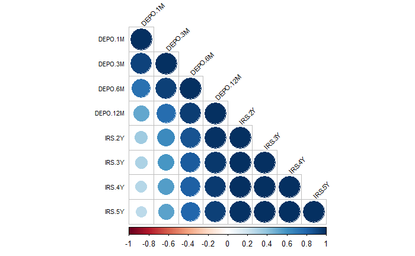

```r
require(corrplot)
corrplot(cor.mat, type="lower", order="original",
         tl.col="black", tl.cex=0.7, tl.srt=45)  # las correlaciones positivas en azul, las negativas en rojo
```

La opción

> type=lower

hace referencia a cómo queremos visualizar la matriz, si por debajo, completa o por encima de la diagonal principal, mientras que la opción

> addrect = 3

añade tres rectángulos de color a las agrupaciones generadas con `order="hclust"`, que sustituye el orden orignal (dado por el anterior `order="original"`):

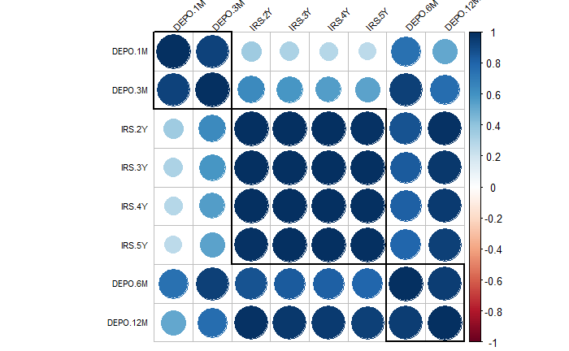

```r
corrplot(cor.mat, type="full", order="hclust", addrect = 3,
         tl.col="black", tl.cex=0.7, tl.srt=45)
```

Podemos asimismo visualizar un *chart* de correlaciones con el paquete `PerformanceAnalytics`, que cargamos:

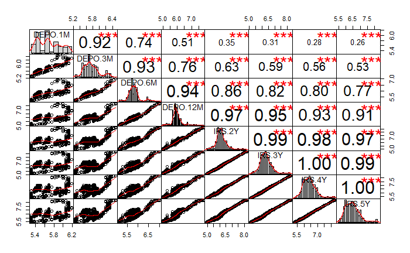

```r
#install.packages("PerformanceAnalytics")
require(PerformanceAnalytics)
chart.Correlation(TIUSD.act, histogram=TRUE, pch=19)
```

También podemos probar con un mapa de calor; definimos en primer lugar la paleta de colores que queremos emplear.

Nota: en relación con el uso de paletas de colores y de degradados, [recomiendo este sencillo post de R-Bloggers](https://www.r-bloggers.com/r-using-rcolorbrewer-to-colour-your-figures-in-r/)]

```r
col = colorRampPalette(c("red", "white", "blue"))(20)
```

para llevar entonces el mapa de calor (opción `symm=TRUE` porque la matriz es simétrica):

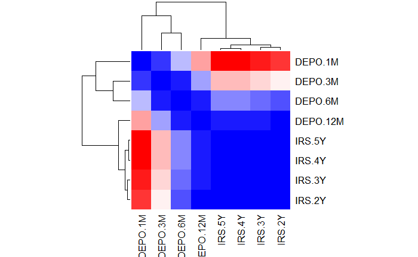

```r
heatmap(x = cor.mat, col = col, symm = TRUE)
```

### Índice KMO y prueba de esfericidad de Bartlett para verificar la idoneidad del ACP - ANFAC

El KMO se realiza a partir de la matriz de correlaciones parciales. Obtenemos la inversa de la matriz de correlaciones como

```r
invR = solve(cor.mat)
```

mientras que, para la matriz de correlaciones parciales, empleamos la biblioteca `ppcor`

```r
#install.packages("ppcor")
require(ppcor)
```

Obtenemos en primer lugar la matriz sin NA’s

```r
TIUSD.act.C=TIUSD.act[complete.cases(TIUSD.act),]
```

para solicitar entonces una lista con elementos como la matriz de correlaciones parciales (estimate), los p-valores, el valor del estadístico t (t-statistic), el tamaño muestral (n), etc, mediante

```r
p.cor.mat=pcor(TIUSD.act.C)
```

```
The inverse of variance-covariance matrix is calculated using Moore-Penrose generalized matrix invers due to its determinant of zero.
```

para así conseguir la matriz de corrleaciones parciales a partir de “$estimate”

```r
p.cor.mat2=as.matrix(p.cor.mat$estimate)
p.cor.mat2
```

```
            [,1]         [,2]        [,3]         [,4]        [,5]        [,6]         [,7]         [,8]
[1,]  1.00000000  0.679926034 -0.06943282 -0.207826871 -0.07010032  0.10037673 -0.067479998  0.027608026
[2,]  0.67992603  1.000000000  0.72131106 -0.147555159  0.03650162 -0.06329169  0.009749124  0.023857597
[3,] -0.06943282  0.721311056  1.00000000  0.629146535  0.10761455 -0.12399391  0.053365577  0.012276707
[4,] -0.20782687 -0.147555159  0.62914653  1.000000000  0.14615991  0.04814215 -0.059353472  0.007032528
[5,] -0.07010032  0.036501625  0.10761455  0.146159911  1.00000000  0.86453820 -0.162938118 -0.331249179
[6,]  0.10037673 -0.063291690 -0.12399391  0.048142150  0.86453820  1.00000000  0.588039893 -0.068468995
[7,] -0.06748000  0.009749124  0.05336558 -0.059353472 -0.16293812  0.58803989  1.000000000  0.838403749
[8,]  0.02760803  0.023857597  0.01227671  0.007032528 -0.33124918 -0.06846900  0.838403749  1.000000000
```

Procedemos a calcular el KMO global

```r
kmo.num = sum(cor.mat^2) - sum(diag(cor.mat^2))
kmo.denom = kmo.num + (sum(p.cor.mat2^2) - sum(diag(p.cor.mat2^2)))
kmo = kmo.num/kmo.denom
```

Calculamos ahora el MSA o KMO parcial para cada una de las variables:

```r
p.cor.mat2=data.frame(p.cor.mat2)
rownames(p.cor.mat2) = c(rownames(cor.mat))
colnames(p.cor.mat2)=c(colnames(cor.mat))
for (j in 1:ncol(TIUSD.act)){
        kmo_j.num <- sum(cor.mat[,j]^2) - cor.mat[j,j]^2
        kmo_j.denom <- kmo_j.num + (sum(p.cor.mat2[,j]^2) - p.cor.mat2[j,j]^2)
        kmo_j <- round(kmo_j.num/kmo_j.denom,4)
        print(paste(colnames(TIUSD.act)[j],"=",kmo_j))
        }
```

```
[1] "DEPO.1M = 0.7919"
[1] "DEPO.3M = 0.7811"
[1] "DEPO.6M = 0.8403"
[1] "DEPO.12M = 0.9167"
[1] "IRS.2Y = 0.8483"
[1] "IRS.3Y = 0.8164"
[1] "IRS.4Y = 0.8191"
[1] "IRS.5Y = 0.8537"
```

En cuanto al test de Bartlett, no será válido si el número de observaciones supera las 100, así que muestreamos

```r
cor.mat
```

```
         DEPO.1M DEPO.3M DEPO.6M DEPO.12M IRS.2Y IRS.3Y IRS.4Y IRS.5Y
DEPO.1M     1.00    0.92    0.74     0.51   0.35   0.31   0.28   0.26
DEPO.3M     0.92    1.00    0.93     0.76   0.63   0.58   0.55   0.53
DEPO.6M     0.74    0.93    1.00     0.94   0.86   0.83   0.81   0.79
DEPO.12M    0.51    0.76    0.94     1.00   0.98   0.96   0.95   0.93
IRS.2Y      0.35    0.63    0.86     0.98   1.00   1.00   0.99   0.98
IRS.3Y      0.31    0.58    0.83     0.96   1.00   1.00   1.00   0.99
IRS.4Y      0.28    0.55    0.81     0.95   0.99   1.00   1.00   1.00
IRS.5Y      0.26    0.53    0.79     0.93   0.98   0.99   1.00   1.00
```

```r
n = nrow(TIUSD.act)
p = ncol(TIUSD.act)
chi2 = -(n-1-(2*p+5)/6)*log(det(cor.mat))
ddl = p*(p-1)/2
```

Muestreamos 70 observaciones y aplicamos el test (rebajando a 25 observaciones, la conclusión es la misma)

```r
set.seed(1234)
TIUSD.mas=TIUSD.act[sample(nrow(TIUSD.act), 70), ]
n = nrow(TIUSD.mas)
p = ncol(TIUSD.mas)
chi2 = -(n-1-(2*p+5)/6)*log(det(cor.mat))
ddl = p*(p-1)/2
print(chi2)
```

```
[1] 1698.146
```

```r
print(ddl)
```

```
[1] 28
```

```r
print(pchisq(chi2,ddl,lower.tail=F))
```

```
[1] 0
```

Podemos también aplicarlo desde el paque `psych`, que cargamos; el resulado es el mismo

```r
require(psych)
print(cortest.bartlett(cor.mat, n=nrow(TIUSD.mas)))
```

```
$`chisq`
[1] 1698.146

$p.value
[1] 0

$df
[1] 28
```

## IDENTIFICACIÓN DE LOS COMPONENTES PRINCIPALES

Para ello, podemos usar varias opciones de identificación; por ejemplo, la siguiente proviene de `FactoMineR`:

> PCA(X, scale.unit = TRUE, ncp = 5, graph = TRUE) X: data frame con las observaciones por filas scale.unit : valor lógico. Si TRUE es que los datos se escalarán a varianza unitaria antes del análisis. Esta normalización evita la dominación de ciertas variables debido a su mayor dimensión. Si trabajamos con la matriz R será FALSE ncp: Número de dimensiones en la solución final; en ACP debería ser igual al nº original de variables graph: valor lógico; muestra un gráfico si TRUE

```
Missing values are imputed by the mean of the variable: you should use the imputePCA function of the missMDA package
```

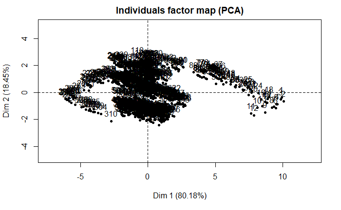

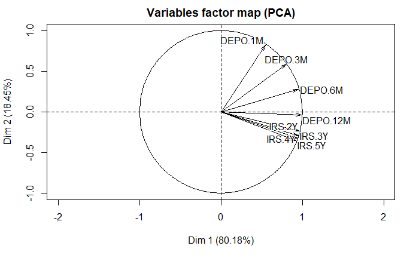

```r
TIUSD.acp = PCA(TIUSD.act, scale.unit = TRUE, ncp = ncol(TIUSD.act), graph = TRUE)
```

Aqui, se sustituye los NA por la media de cada variable; podemos hacerlo también sobre el objeto que continen las observaciones completas, `TIUSD.act.c`.

Observamos el objeto list creado con el proceso PCA

```r
print(TIUSD.acp)
```

```
**Results for the Principal Component Analysis (PCA)**
The analysis was performed on 949 individuals, described by 8 variables
*The results are available in the following objects:

   name               description
1  "$eig"             "eigenvalues"
2  "$var"             "results for the variables"
3  "$var$coord"       "coord. for the variables"
4  "$var$cor"         "correlations variables - dimensions"
5  "$var$cos2"        "cos2 for the variables"
6  "$var$contrib"     "contributions of the variables"
7  "$ind"             "results for the individuals"
8  "$ind$coord"       "coord. for the individuals"
9  "$ind$cos2"        "cos2 for the individuals"
10 "$ind$contrib"     "contributions of the individuals"
11 "$call"            "summary statistics"
12 "$call$centre"     "mean of the variables"
13 "$call$ecart.type" "standard error of the variables"
14 "$call$row.w"      "weights for the individuals"
15 "$call$col.w"      "weights for the variables"
```

Y mediante la siguiente orden, obtenemos los autovalores de los CCPP y el tanto por ciento de la varianza explicada

```r
autoval= TIUSD.acp$eig #devuelve
round(autoval, 2)
```

```
       eigenvalue percentage of variance cumulative percentage of variance
comp 1       6.41                  80.18                             80.18
comp 2       1.48                  18.45                             98.63
comp 3       0.08                   0.98                             99.61
comp 4       0.02                   0.29                             99.90
comp 5       0.00                   0.06                             99.96
comp 6       0.00                   0.04                            100.00
comp 7       0.00                   0.00                            100.00
comp 8       0.00                   0.00                            100.00
```

Representamos ahora gráficamente los autovalores,

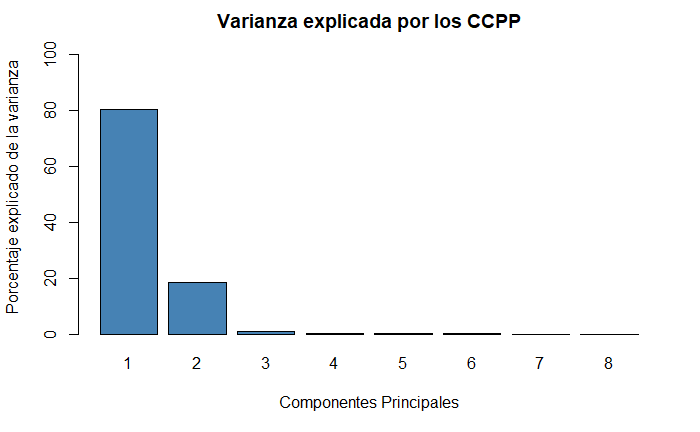

```r
barplot(autoval[, 2], names.arg=1:nrow(autoval),
        main = "Varianza explicada por los CCPP",
        xlab = "Componentes Principales",
        ylab = "Porcentaje explicado de la varianza",
        col ="steelblue",
        ylim=c(0,105))
```

Y añadimos una línea que conecte las barras y otra que informe del porcentaje acumulado de la varianza explicada

```r
barplot(autoval[, 2], names.arg=1:nrow(autoval),
        main = "Varianza explicada por los CCPP",
        xlab = "Componentes Principales",
        ylab = "Porcentaje explicado de la varianza",
        col ="steelblue",
        ylim=c(0,105))
lines(x = 1:nrow(autoval), autoval[, 2],
      type="b", pch=19, col = "red")
```

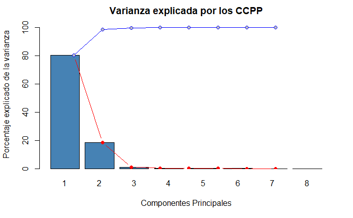

```r
lines(x = 1:nrow(autoval), autoval[, 3],
      type="o", pch=21, col = "blue", bg="grey")
```

Como vemos, sólo el 1er CP explica más del $80\%$ de la varianza, los dos primeros el $98\%$. La reducción de dimensión es enorme.

Hacemos el mismo gráfico con el pack `factoextra`:

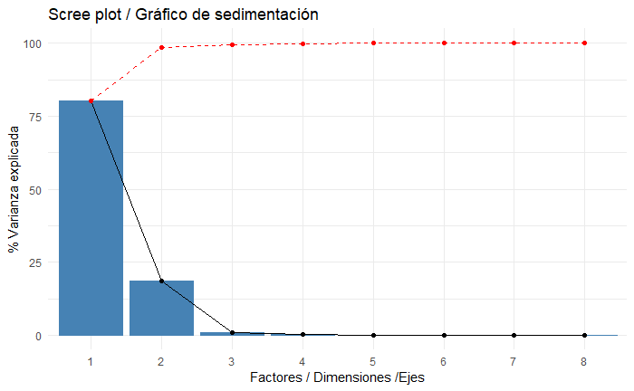

```r
fviz_screeplot(TIUSD.acp)+
        labs(title="Scree plot / Gráfico de sedimentación", x="Factores / Dimensiones /Ejes", y="% Varianza explicada")+
        geom_line(aes( y = autoval[,3]), linetype="dashed", color = "red")+
        geom_point(y = autoval[,3], color="red")+
        theme_minimal()
```

Podemos representar los individuos o la variables en un mapa de componentes

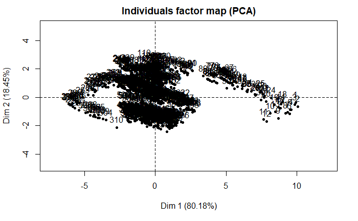

```r
plot.PCA(TIUSD.acp, axes = c(1,2), choix=c("ind"))
```

> axes

Señala qué componentes queremos utilizar en el mapa; máximo dos de ellos.

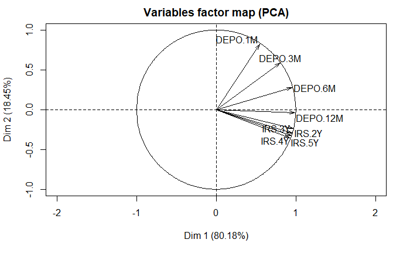

```r
plot.PCA(TIUSD.acp, axes = c(1,2), choix=c("var"))
```

> choix=c(ind)

si quisiéramos representar los individuos en vez de las variables.

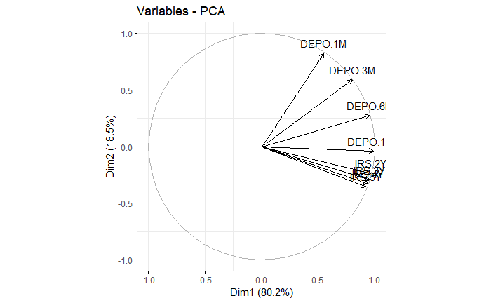

```r
fviz_pca_var(TIUSD.acp)
```

Las coordenadas de las variables en el espacio de CCPP vienen dadas por

```r
TIUSD.acp$var$coord
```

[output not shown]

mientras que las de las variables (las seis primeras) lo son mediante

```r
head(TIUSD.acp$ind$coord)
```

```
      Dim.1      Dim.2      Dim.3      Dim.4       Dim.5       Dim.6        Dim.7       Dim.8
1  9.917324 -0.3654402 -0.8199462 -0.2059365 0.088759341 -0.01302246 -0.008879372 0.018631923
2 10.058253 -0.6564596 -0.9466088 -0.3096553 0.106005496  0.06610553  0.032970115 0.011979886
3  9.856261 -0.5268259 -1.0143307 -0.3524716 0.012303237  0.12627757  0.029189192 0.017466522
4  9.606851 -0.8602942 -0.8056809 -0.3322105 0.081372488 -0.01665557  0.033422522 0.025380448
5  9.506565 -0.8875644 -0.8408907 -0.4389890 0.001921612  0.03157424 -0.007983327 0.002318366
6  9.483012 -1.1552834 -0.6913045 -0.2057888 0.052150494  0.06283035  0.012678477 0.005243023
```

La calidad de la representación viene dada por la medida $cos^2$, los cuadrados de las cargas factoriales o comunalidades

```r
TIUSD.acp$var$cos2
```

```
             Dim.1       Dim.2        Dim.3        Dim.4        Dim.5        Dim.6        Dim.7        Dim.8
DEPO.1M  0.3009888 0.675675995 0.0169301814 0.0063605998 4.395446e-05 4.814447e-07 3.763533e-12 2.690714e-10
DEPO.3M  0.6415347 0.347366225 0.0001515030 0.0098577680 9.607187e-04 1.290484e-04 1.476423e-09 3.048736e-11
DEPO.6M  0.9075049 0.076041482 0.0135834125 0.0005929828 1.212720e-03 1.064448e-03 2.611490e-08 1.372915e-08
DEPO.12M 0.9751050 0.001664305 0.0197926922 0.0018027928 2.034483e-04 1.431715e-03 1.466437e-08 6.355785e-10
IRS.2Y   0.9382477 0.055462974 0.0018200666 0.0027009204 1.455107e-03 2.737739e-04 3.479404e-05 4.706285e-06
IRS.3Y   0.9118558 0.086657436 0.0007048845 0.0003667052 2.857103e-04 5.612167e-05 3.747313e-05 3.584840e-05
IRS.4Y   0.8839244 0.108437229 0.0073338703 0.0002026568 2.908106e-05 5.199738e-08 3.862831e-05 3.405073e-05
IRS.5Y   0.8548721 0.124794393 0.0179521467 0.0017071822 5.635698e-04 6.069447e-05 4.611120e-05 3.776747e-06
```

Comprobamos, como ejercicio, que la suma de las comunalidades es uno en cada variable

```r
apply(as.matrix(TIUSD.acp$var$cos2), 1, sum)
```

```
 DEPO.1M  DEPO.3M  DEPO.6M DEPO.12M   IRS.2Y   IRS.3Y   IRS.4Y   IRS.5Y
       1        1        1        1        1        1        1        1
```

Y comprobamos que el autovalor de cada factor $j $es la suma de los cuadrados de los $a_{ij}$

```r
CP1=TIUSD.acp$var$coord[,1]
CP1
```

```
  DEPO.1M   DEPO.3M   DEPO.6M  DEPO.12M    IRS.2Y    IRS.3Y    IRS.4Y    IRS.5Y
0.5486245 0.8009586 0.9526305 0.9874741 0.9686318 0.9549114 0.9401726 0.9245930
```

```r
CCP2=CP1^2
CCP2
```

```
  DEPO.1M   DEPO.3M   DEPO.6M  DEPO.12M    IRS.2Y    IRS.3Y    IRS.4Y    IRS.5Y
0.3009888 0.6415347 0.9075049 0.9751050 0.9382477 0.9118558 0.8839244 0.8548721
```

```r
sum(CCP2)
```

```
[1] 6.414034
```

Cuando, para representar una variable, son necesarios más de 2 CCPP, la variable estará alejada del borde del círculo (no es el caso); las variables que en los 2 CCPP que definen el mapa quedan cercanas al centro tienen poca posibilidad de ser correctamente representadas por ellos. El siguiente gráfico plantea en escala de colores la contribución de los factores extraídos en la explicación de cada variable, es decir *su comunalidad*

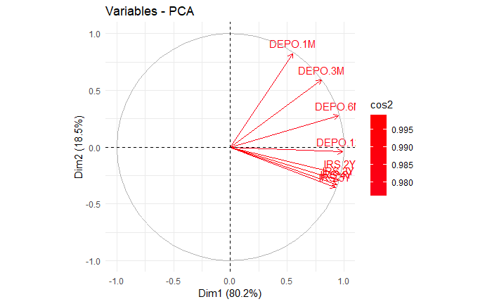

```r
fviz_pca_var(TIUSD.acp, col.var="cos2") +
        scale_color_gradient2(low="white", mid="blue",
                              high="red", midpoint=0.5) + theme_minimal()
```

También podemos querer conocer la contribución de las variables a los CCPP. A mayor valor de la medida (expresado como porcentaje de la relación por cociente entre la comunalidad de la variable respecto del autovalor del CP), mayor contribución de la variable.

```r
TIUSD.acp$var$contrib
```

```
            Dim.1      Dim.2      Dim.3      Dim.4      Dim.5       Dim.6        Dim.7        Dim.8
DEPO.1M   4.69266 45.7744040 21.6308295 26.9612814  0.9245182  0.01596125 2.396408e-06 3.432172e-04
DEPO.3M  10.00205 23.5327021  0.1935677 41.7850620 20.2073220  4.27831876 9.401041e-04 3.888851e-05
DEPO.6M  14.14874  5.1515128 17.3548335  2.5135327 25.5078053 35.28943501 1.662851e-02 1.751237e-02
DEPO.12M 15.20268  0.1127501 25.2881135  7.6416699  4.2792388 47.46539876 9.337455e-03 8.107196e-04
IRS.2Y   14.62804  3.7573994  2.3254063 11.4486490 30.6060642  9.07637799 2.215490e+01 6.003157e+00
IRS.3Y   14.21657  5.8707021  0.9005950  1.5543885  6.0095009  1.86059162 2.386080e+01 4.572685e+01
IRS.4Y   13.78110  7.3461978  9.3701121  0.8590205  0.6116778  0.00172386 2.459635e+01 4.343381e+01
IRS.5Y   13.32815  8.4543317 22.9365424  7.2363960 11.8538728  2.01219276 2.936104e+01 4.817474e+00
```

Y, también como ejercicio, comprobamos que suma 100 por columnas

```r
apply(as.matrix(TIUSD.acp$var$contrib), 2, sum)
```

```
Dim.1 Dim.2 Dim.3 Dim.4 Dim.5 Dim.6 Dim.7 Dim.8
  100   100   100   100   100   100   100   100
```

Esa contribución puede visualizarse del modo siguiente:

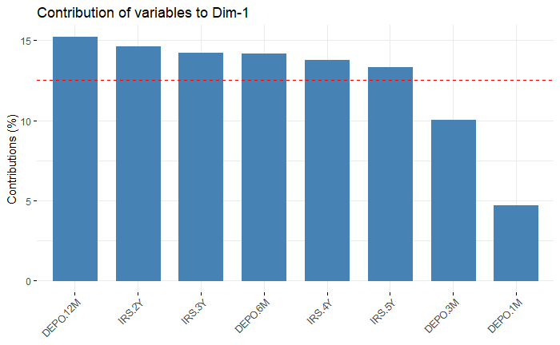

```r
fviz_contrib(TIUSD.acp, choice = "var", axes = 1)
```

> axes=1 se refiere al nº de eje o CP que queremos representar;

La línea roja representa la uniformidad en la representación: si cada variable tuviese un poder explicativo uniforme cada una contribuiría en $\dfrac{1}{p}$ (aquí, $\dfrac{1}{8}=12.5\%$); un valor por encima de este significa una contribución mayor.

*Compruébese como para el eje 2 los depósitos a corto plazo son esenciales*

Para conocer la contribución de las variables a la explicación de un número concreto de CCPP, simplemente sumamos el producto de la contribución de la vble en cada uno de ellos por el valor propio de cada uno de ellos:

```r
A=as.matrix(TIUSD.acp$var$contrib[,1:2])/100  # lo expresamos en tanto por uno
B=as.matrix(TIUSD.acp$eig[1:2,1])
A%*%B # producto matricial
```

```
              [,1]
DEPO.1M  0.9766648
DEPO.3M  0.9889010
DEPO.6M  0.9835464
DEPO.12M 0.9767693
IRS.2Y   0.9937106
IRS.3Y   0.9985133
IRS.4Y   0.9923617
IRS.5Y   0.9796665
```

### Representación de las variables que más contribuyen a la explicación de un factor

Las tres variables que más contribuyen al eje 1

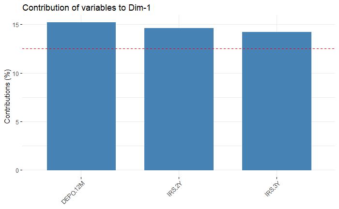

```r
fviz_contrib(TIUSD.acp, choice = "var", axes = 1, top = 3)
```

Y las tres que más contribuyen al eje 2

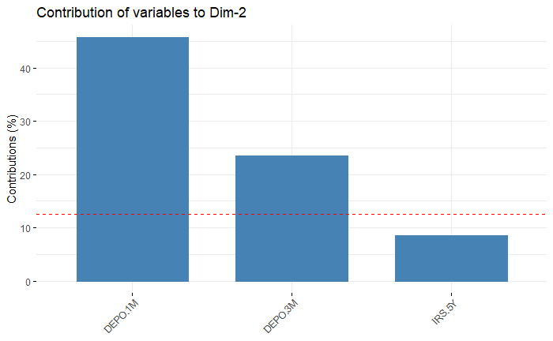

```r
fviz_contrib(TIUSD.acp, choice = "var", axes = 2, top = 3)
```

Y, en cuanto a la contribución de cada variable a la explicación de los dos ejes principales, podemos verlo en escala de color

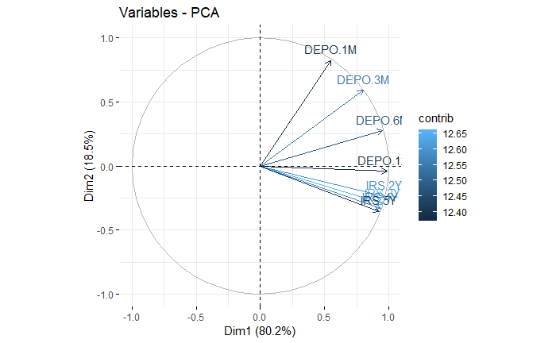

```r
fviz_pca_var(TIUSD.acp, col.var="contrib")
```

… que podemos modificar fácilmente:

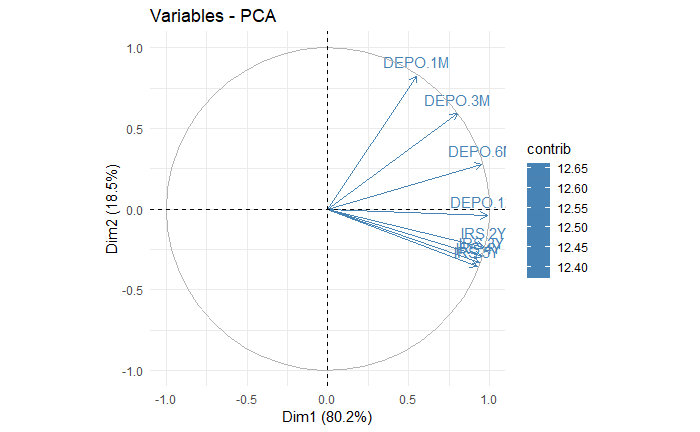

```r
fviz_pca_var(TIUSD.acp, col.var="contrib") +
        scale_color_gradient2(low="steelblue", mid="white",
                              high="darkblue", midpoint=50) +
        theme_minimal()
```

Como podemos observar, no existe apenas variación por la enorme capacidad de explicación de todas las variables.

La contribución de las observaciones degradadas por importancia en la explicación podemos representarla con la siguiente orden:

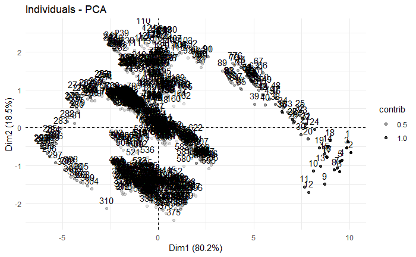

```r
fviz_pca_ind(TIUSD.acp, alpha.ind="contrib") +
        theme_minimal()
```

### Rotaciones factoriales.

Para ello, emplearemos la librería `prcomp`, cargada por defecto en la instalación básica dentro de `stats`.

En primer lugar, normalizamos los datos completos

```r
TIUSD.norm = data.frame (scale (TIUSD.act.C))
```

Comprobamos que está correctamente efectuada la operación de normalización,

```r
summary(TIUSD.norm)
```

```
    DEPO.1M           DEPO.3M            DEPO.6M             DEPO.12M           IRS.2Y            IRS.3Y            IRS.4Y
 Min.   :-1.5397   Min.   :-1.99141   Min.   :-2.256534   Min.   :-2.2853   Min.   :-2.4221   Min.   :-2.3730   Min.   :-2.2861
 1st Qu.:-0.9990   1st Qu.:-0.77964   1st Qu.:-0.671302   1st Qu.:-0.4717   1st Qu.:-0.4690   1st Qu.:-0.4974   1st Qu.:-0.5548
 Median :-0.1346   Median :-0.05567   Median :-0.000387   Median :-0.1254   Median :-0.1139   Median :-0.1223   Median :-0.1161
 Mean   : 0.0000   Mean   : 0.00000   Mean   : 0.000000   Mean   : 0.0000   Mean   : 0.0000   Mean   : 0.0000   Mean   : 0.0000
 3rd Qu.: 0.7626   3rd Qu.: 0.48827   3rd Qu.: 0.292944   3rd Qu.: 0.2985   3rd Qu.: 0.4095   3rd Qu.: 0.4658   3rd Qu.: 0.4877
 Max.   : 2.0448   Max.   : 2.84792   Max.   : 3.606953   Max.   : 3.9678   Max.   : 3.7457   Max.   : 3.5547   Max.   : 3.4314
     IRS.5Y
 Min.   :-2.18077
 1st Qu.:-0.60558
 Median :-0.09979
 Mean   : 0.00000
 3rd Qu.: 0.49753
 Max.   : 3.36851
```

```r
round(sapply(TIUSD.norm, mean, na.rm = T), 2)
```

```
 DEPO.1M  DEPO.3M  DEPO.6M DEPO.12M   IRS.2Y   IRS.3Y   IRS.4Y   IRS.5Y
       0        0        0        0        0        0        0        0
```

```r
sapply(TIUSD.norm, sd, na.rm=T)
```

```
 DEPO.1M  DEPO.3M  DEPO.6M DEPO.12M   IRS.2Y   IRS.3Y   IRS.4Y   IRS.5Y
       1        1        1        1        1        1        1        1
```

Y aplicamos el ACP

```r
TI.acp=prcomp(TIUSD.norm )
summary(TI.acp)
```

```
Importance of components:
                          PC1    PC2     PC3     PC4     PC5     PC6     PC7   PC8
Standard deviation     2.5420 1.2079 0.24088 0.11552 0.06948 0.05349 0.01311 9e-03
Proportion of Variance 0.8077 0.1824 0.00725 0.00167 0.00060 0.00036 0.00002 1e-05
Cumulative Proportion  0.8077 0.9901 0.99734 0.99901 0.99961 0.99997 0.99999 1e+00
```

Efectuamos las oportunas comprobaciones,

```r
TI.acp$sdev
```

```
[1] 2.54195802 1.20794908 0.24087793 0.11551854 0.06947986 0.05349123 0.01311355 0.00900036
```

```r
(TI.acp$sdev)^2
```

```
[1] 6.461551e+00 1.459141e+00 5.802218e-02 1.334453e-02 4.827451e-03 2.861312e-03 1.719653e-04 8.100649e-05
```

```r
sum((TI.acp$sdev)^2)
```

```
[1] 8
```

Y generamos en gráfico de saturación, o *screeplot*

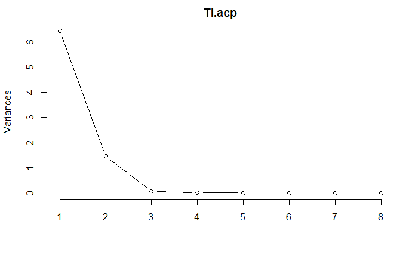

```r
screeplot(TI.acp, type="lines")
```

Cargamos la librería `qcc`, de gráficos de control de calidad

```r
require(qcc)
```

Calculamos las varianzas

```r
varianzas = TI.acp$sdev^2
```

Y generamos un gráfico de Pareto

```
Pareto chart analysis for varianzas
       Frequency    Cum.Freq.   Percentage Cum.Percent.
  A 6.461551e+00 6.461551e+00 8.076938e+01 8.076938e+01
  B 1.459141e+00 7.920692e+00 1.823926e+01 9.900864e+01
  C 5.802218e-02 7.978714e+00 7.252772e-01 9.973392e+01
  D 1.334453e-02 7.992058e+00 1.668067e-01 9.990073e+01
  E 4.827451e-03 7.996886e+00 6.034314e-02 9.996107e+01
  F 2.861312e-03 7.999747e+00 3.576640e-02 9.999684e+01
  G 1.719653e-04 7.999919e+00 2.149566e-03 9.999899e+01
  H 8.100649e-05 8.000000e+00 1.012581e-03 1.000000e+02
```

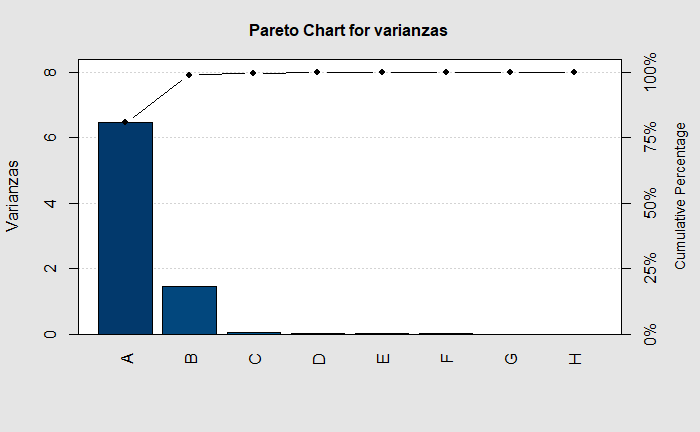

```r
pareto.chart (varianzas, ylab="Varianzas")
```

En cuanto a la rotación, la obtenemos como

```r
TI.acp$rotation
```

```
                PC1         PC2         PC3         PC4         PC5          PC6          PC7          PC8
DEPO.1M  -0.2224648 -0.67165893 -0.58679440  0.38019372  0.10209777 -0.008272761  0.001399062 -0.003795108
DEPO.3M  -0.3129580 -0.49562942  0.23148694 -0.57622986 -0.44405793  0.271202504 -0.005626290  0.003438263
DEPO.6M  -0.3762142 -0.22268754  0.43173386 -0.08508011  0.46280345 -0.633031294 -0.012532451  0.012948214
DEPO.12M -0.3900404  0.04378184  0.41806976  0.43616824  0.26850625  0.639309249 -0.009688755 -0.004556345
IRS.2Y   -0.3810834  0.19944501  0.05265247  0.35050105 -0.56005325 -0.279242624  0.473928858 -0.270424166
IRS.3Y   -0.3758681  0.24236117 -0.12013900  0.09938056 -0.26330079 -0.126455772 -0.452361373  0.696939868
IRS.4Y   -0.3712997  0.26766795 -0.26674633 -0.17695781  0.06237662  0.011535747 -0.531666634 -0.633505674
IRS.5Y   -0.3667877  0.28557973 -0.39057701 -0.40235429  0.34529432  0.151113366  0.536476160  0.199001283
```

ofreciéndonos la siguiente orden las cargas del 1er eje

```r
TI.acp$rotation[,1]
```

```
   DEPO.1M    DEPO.3M    DEPO.6M   DEPO.12M     IRS.2Y     IRS.3Y     IRS.4Y     IRS.5Y
-0.2224648 -0.3129580 -0.3762142 -0.3900404 -0.3810834 -0.3758681 -0.3712997 -0.3667877
```

Al haber normalizado los factores, la suma del cuadrado de las cargas debe ser 1:

```r
sum(TI.acp$rotation[,1]^2)
```

```
[1] 1
```

En cuanto a las cargas de la primera variable,

```r
TI.acp$rotation[1,]
```

```
         PC1          PC2          PC3          PC4          PC5          PC6          PC7          PC8
-0.222464788 -0.671658935 -0.586794403  0.380193724  0.102097774 -0.008272761  0.001399062 -0.003795108
```

```r
sum(TI.acp$rotation[1,]^2)
```

```
[1] 1
```

Por último, efectuamos la rotación Varimax mediante

```r
TI.rot = principal(TIUSD.norm, nfactors=8, rotate="varimax")
```

Obtenemos las comunalidades

```r
TI.rot$communality
```

```
 DEPO.1M  DEPO.3M  DEPO.6M DEPO.12M   IRS.2Y   IRS.3Y   IRS.4Y   IRS.5Y
       1        1        1        1        1        1        1        1
```

y las cargas factoriales, comprobándose fácilmente que `sum(rot.loadings^2)` devuelve el “autovalor rotado”

```r
TI.rot$loadings
```

```
Loadings:
         RC1    RC2    RC3    RC4    RC5    RC6    RC8    RC7
DEPO.1M          0.991
DEPO.3M   0.376  0.915  0.106
DEPO.6M   0.679  0.709  0.184
DEPO.12M  0.873  0.450  0.184
IRS.2Y    0.954  0.281
IRS.3Y    0.972  0.232
IRS.4Y    0.979  0.201
IRS.5Y    0.982  0.179

                 RC1   RC2   RC3   RC4   RC5   RC6 RC8 RC7
SS loadings    5.148 2.731 0.093 0.016 0.008 0.004   0   0
Proportion Var 0.644 0.341 0.012 0.002 0.001 0.000   0   0
Cumulative Var 0.644 0.985 0.996 0.998 0.999 1.000   1   1
```

## Componentes suplementarios

Los componentes *suplementarios* (variables o individuos) no se emplean en la determinación de las componentes principales. Sus valores se predicen o ajustan en virtud del análisis previamente efectuado sobre individuos y variables *activos*.

### Especificación de los elementos suplementarios

Para proceder a su especificación, esto es, a definir cuáles son a efectos del análisis, se procede como sigue:

> PCA(X, ind.sup = NULL, quanti.sup = NULL, quali.sup = NULL, graph = TRUE)

Siendo

- `x`, un data frame donde los individuos aparecen por filas y las varibles por columnas;
- `ind.sup` es un vector numérico que especifica los valores de los individuos suplementarios;
- `quanti.sup`, `quali.sup` son vectores numéricos que especifican los índices de las variables suplementarias, respectivamente numéricas o categóricas;
- `graph` es la orden para señalar si queremos o no una representación gráfica.

En nuestro caso, procederíamos como sigue:

```r
supl.acp= PCA(TIUSD[,-1], ind.sup= 950:978,  quanti.sup = 10, graph=FALSE)
```

```
Missing values are imputed by the mean of the variable: you should use the imputePCA function of the missMDA package
```

En cuanto a la variable en escala métrica, el bono a 10 años, su resultados previstos en términos de coordenadas, correlaciones y $cos^2$ viene dados por

```r
supl.acp$quanti.sup
```

```
$`coord`
            Dim.1      Dim.2     Dim.3       Dim.4       Dim.5
IRS.10Y 0.8926572 -0.3577866 0.2538224 -0.08398728 -0.04800988

$cor
            Dim.1      Dim.2     Dim.3       Dim.4       Dim.5
IRS.10Y 0.8926572 -0.3577866 0.2538224 -0.08398728 -0.04800988

$cos2
            Dim.1     Dim.2      Dim.3       Dim.4       Dim.5
IRS.10Y 0.7968369 0.1280112 0.06442582 0.007053863 0.002304948
```

Para visualizarla junto con las variables activas, haremos

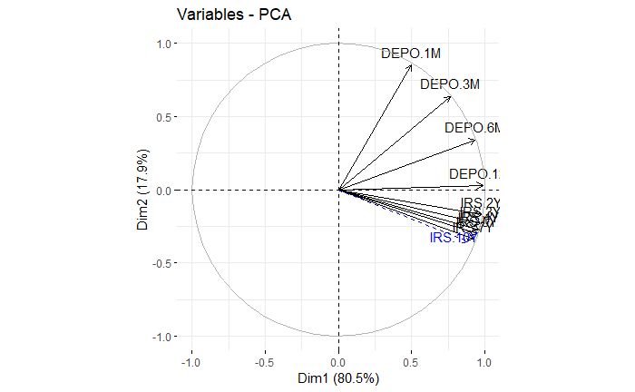

```r
fviz_pca_var(supl.acp)
```

que podemos mejorar mediante

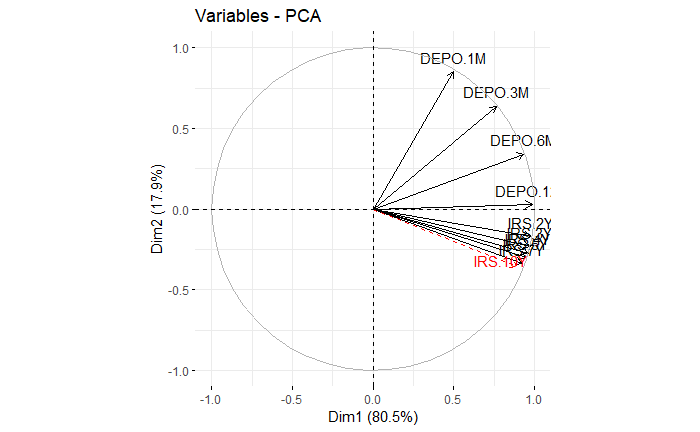

```r
fviz_pca_var(supl.acp,
             col.var = "black",     #  variables activas
             col.quanti.sup = "red" #  variables suplementarias métricas
             )
```

Si quisiéramos visualizar sólo las suplementarias, procederíamos así:

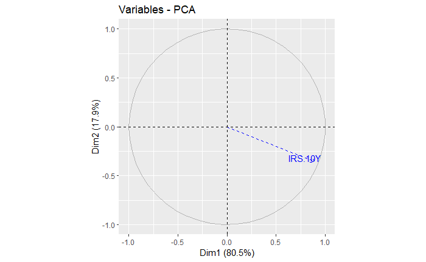

```r
fviz_pca_var(supl.acp, invisible = "var")
```

mientras que si lo quisiésemos hacer respecto de las activas, ocultaríamos las suplementarias de modo análogo:

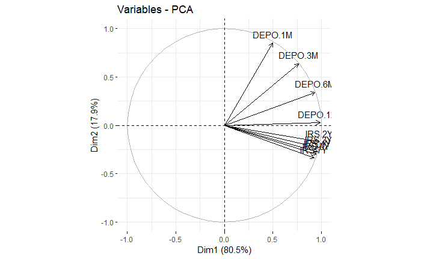

```r
fviz_pca_var(supl.acp, invisible = "quanti.sup")
```

En cuanto a las observaciones suplementarias, el proceso es similar, e igualmente sencillo. Sus valores previstos vienen dados por

```r
supl.acp$ind
```

[output not shown]

que podemos visualizar del modo siguiente:

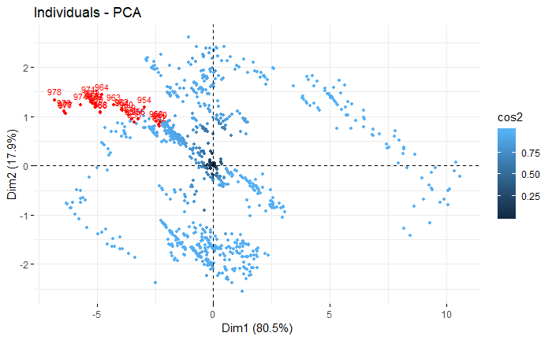

```r
fviz_pca_ind(supl.acp, col.ind= "cos2", col.ind.sup = "red", repel = FALSE,
             pointsize=1,
             labelsize = 3,
             label = "sup",
             #jitter = list(what = "label", width = NULL, height = NULL)
             )
```

También podemos seleccionar sólo a aquellos individuos que tengan un alto $cos^2$:

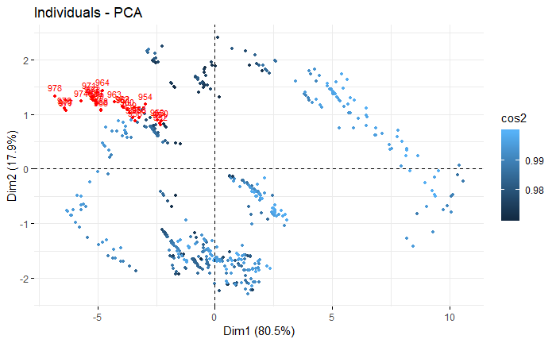

```r
fviz_pca_ind(supl.acp, col.ind= "cos2", col.ind.sup = "red", repel = FALSE,
             pointsize=1,
             labelsize = 3,
             label = "sup",
             select.ind = list(cos2=0.97),
             #jitter = list(what = "label", width = NULL, height = NULL)
             )
```

o, incluso, a los 40 con mayor $cos^2$ :

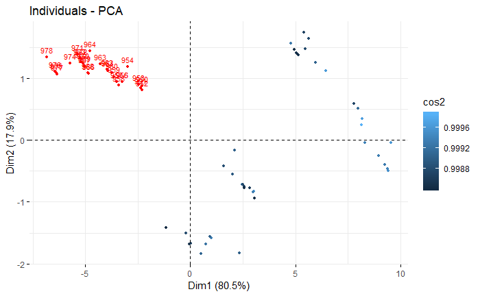

```r
fviz_pca_ind(supl.acp, col.ind= "cos2", col.ind.sup = "red", repel = FALSE,
             pointsize=1,
             labelsize = 3,
             label = "sup",
             select.ind = list(cos2=40),
             #jitter = list(what = "label", width = NULL, height = NULL)
             )
```

Esta posibilidad ofrecida por la opción `list` nos permite asimismo ver la contribución de las observaciones (mediante `select.ind = list(contrib=40)`) o incluso visualizar sólo algunos en concreto (mediante `select.ind = list("50", "150", "525", "739")`, por ejemplo)